# no lpi models

## lec_2 - Specialist

```r
dotchart(SES$SES_lec_2, group = SES$trmt, pch = 19)
with(FS_comps, bartlett.test(SES_lec_2 ~ trmt))
with(KT_comps, bartlett.test(SES_lec_2 ~ trmt))
with(VL_comps, bartlett.test(SES_lec_2 ~ trmt))
with(FS_comps, ad.test(SES_lec_2))
with(KT_comps, ad.test(SES_lec_2))
with(VL_comps, ad.test(SES_lec_2))
```

####Frances

```r
FS_lec_2.mod.full <- glm(SES_lec_2 ~ trmt + pland + enn, family = gaussian, data = FS_comps)
summary(FS_lec_2.mod.full)
step(FS_lec_2.mod.full)
```

```r
FS_lec_2.mod.red <- glm(SES_lec_2 ~ pland, family = gaussian, data = FS_comps)
summary(FS_lec_2.mod.red)
qqnorm(resid(FS_lec_2.mod.red))
qqline(resid(FS_lec_2.mod.red))
plot(simulateResiduals(FS_lec_2.mod.red))
densityPlot(rstudent(FS_lec_2.mod.red)) # check density estimate of the distribution of residuals
outlierTest(FS_lec_2.mod.red)
influenceIndexPlot(FS_lec_2.mod.red, vars = c("Cook"), id = list(n = 3))

Anova(FS_lec_2.mod.red)

effect_plot(FS_lec_2.mod.red, pred = pland, interval = TRUE, partial.residuals = TRUE, x.label = ' (PLAND)', y.label = 'Standardized Effect Sizes (SES)')


FS_lec_2.mod.null <- glm(SES_lec_2 ~ 1, family = gaussian, data = FS_comps)

# model comparison techniques
anova(FS_lec_2.mod.full, FS_lec_2.mod.red, FS_lec_2.mod.null, test = "F")
AICctab(FS_lec_2.mod.full, FS_lec_2.mod.red, FS_lec_2.mod.null)
```

####Katie

```r
KT_lec_2.mod.full <- glm(SES_lec_2 ~ trmt + pland + enn, family = gaussian, data = KT_comps)
summary(KT_lec_2.mod.full)
step(KT_lec_2.mod.full)
```

```r
KT_lec_2.mod.red <- glm(SES_lec_2 ~ pland, family = gaussian, data = KT_comps)
summary(KT_lec_2.mod.red)
qqnorm(resid(KT_lec_2.mod.red))
qqline(resid(KT_lec_2.mod.red))
plot(simulateResiduals(KT_lec_2.mod.red))
densityPlot(rstudent(KT_lec_2.mod.red)) # check density estimate of the distribution of residuals
outlierTest(KT_lec_2.mod.red)
influenceIndexPlot(KT_lec_2.mod.red, vars = c("Cook"), id = list(n = 3))

Anova(KT_lec_2.mod.red)


effect_plot(KT_lec_2.mod.red, pred = pland, interval = TRUE, partial.residuals = TRUE, x.label = 'Percentage Greenspace (PLAND)', y.label = 'Standardized Effect Sizes (SES)')

KT_lec_2.mod.null <- glm(SES_lec_2 ~ 1, family = gaussian, data = KT_comps)

# model comparison techniques
anova(KT_lec_2.mod.full, KT_lec_2.mod.red, KT_lec_2.mod.null, test = "F")
AICctab(KT_lec_2.mod.full, KT_lec_2.mod.red, KT_lec_2.mod.null)
```

####Vacatn Lots

```r
VL_lec_2.mod.full <- glm(SES_lec_2 ~ trmt + pland + enn, family = gaussian, data = VL_comps)
summary(VL_lec_2.mod.full)
step(VL_lec_2.mod.full)
```

```r
VL_lec_2.mod.red <- glm(SES_lec_2 ~ trmt + pland, family = gaussian, data = VL_comps)
summary(VL_lec_2.mod.red)
qqnorm(resid(VL_lec_2.mod.red))
qqline(resid(VL_lec_2.mod.red))
plot(simulateResiduals(VL_lec_2.mod.red))
densityPlot(rstudent(VL_lec_2.mod.red)) # check density estimate of the distribution of residuals
outlierTest(VL_lec_2.mod.red)
influenceIndexPlot(VL_lec_2.mod.red, vars = c("Cook"), id = list(n = 3))

Anova(VL_lec_2.mod.red)
emmeans(VL_lec_2.mod.red, pairwise ~ trmt)

effect_plot(VL_lec_2.mod.red, pred = trmt, interval = TRUE, partial.residuals = TRUE, x.label = 'TRT', y.label = 'Standardized Effect Sizes (SES)')
effect_plot(VL_lec_2.mod.red, pred = pland, interval = TRUE, partial.residuals = TRUE, x.label = ' (PLAND)', y.label = 'Standardized Effect Sizes (SES)')

VL_lec_2.mod.null <- glm(SES_lec_2 ~ 1, family = gaussian, data = VL_comps)

# model comparison techniques
anova(VL_lec_2.mod.full, VL_lec_2.mod.red, VL_lec_2.mod.null, test = "F")
AICctab(VL_lec_2.mod.full, VL_lec_2.mod.red, VL_lec_2.mod.null)
```

##Nesting—- ## nest_1 - Soil

```r
dotchart(SES$SES_nest_1, group = SES$trmt, pch = 19)
with(FS_comps, bartlett.test(SES_nest_1 ~ trmt))
with(KT_comps, bartlett.test(SES_nest_1 ~ trmt))
with(VL_comps, bartlett.test(SES_nest_1 ~ trmt))
with(FS_comps, ad.test(SES_nest_1))
with(KT_comps, ad.test(SES_nest_1))
with(VL_comps, ad.test(SES_nest_1))
```

So Vacant lots failed normality testing and will use a Kruskal Wallace test instead

####Frances

```r
FS_nest_1.mod.full <- glm(SES_nest_1 ~ trmt + pland + + enn, family = gaussian, data = FS_comps)
summary(FS_nest_1.mod.full)
step(FS_nest_1.mod.full)
```

```r
FS_nest_1.mod.red <- glm(SES_nest_1 ~ trmt, family = gaussian, data = FS_comps)
summary(FS_nest_1.mod.red)
qqnorm(resid(FS_nest_1.mod.red))
qqline(resid(FS_nest_1.mod.red))
plot(simulateResiduals(FS_nest_1.mod.red))
densityPlot(rstudent(FS_nest_1.mod.red)) # check density estimate of the distribution of residuals
outlierTest(FS_nest_1.mod.red)
influenceIndexPlot(FS_nest_1.mod.red, vars = c("Cook"), id = list(n = 3))

#it looks like there is an outlier
FS_nest_1.mod.red2 <- update(FS_nest_1.mod.red, subset = -c(1))
summary(FS_nest_1.mod.red2)
compareCoefs(FS_nest_1.mod.red, FS_nest_1.mod.red2) # compares estimated coefficients and their standard errors

Anova(FS_nest_1.mod.red)
emmeans(FS_nest_1.mod.red, pairwise ~ trmt)

effect_plot(FS_nest_1.mod.red, pred = trmt, interval = TRUE, partial.residuals = TRUE, x.label = '', y.label = 'Standardized Effect Sizes (SES)')

FS_nest_1.mod.null <- glm(SES_nest_1 ~ 1, family = gaussian, data = FS_comps)

# model comparison techniques
anova(FS_nest_1.mod.full, FS_nest_1.mod.red, FS_nest_1.mod.null, test = "F")
AICctab(FS_nest_1.mod.full, FS_nest_1.mod.red, FS_nest_1.mod.null)
```

####Katie

```r
KT_nest_1.mod.full <- glm(SES_nest_1 ~ trmt + pland + enn, family = gaussian, data = KT_comps)
summary(KT_nest_1.mod.full)
step(KT_nest_1.mod.full)
```

```r
KT_nest_1.mod.red <- glm(SES_nest_1 ~ trmt+pland, family = gaussian, data =  KT_comps)
summary(KT_nest_1.mod.red)
qqnorm(resid(KT_nest_1.mod.red))
qqline(resid(KT_nest_1.mod.red))
plot(simulateResiduals(KT_nest_1.mod.red))
densityPlot(rstudent(KT_nest_1.mod.red)) # check density estimate of the distribution of residuals
outlierTest(KT_nest_1.mod.red)
influenceIndexPlot(KT_nest_1.mod.red, vars = c("Cook"), id = list(n = 3))

Anova(KT_nest_1.mod.red)
emmeans(KT_nest_1.mod.red, pairwise ~ trmt)

effect_plot(KT_nest_1.mod.red, pred = trmt, interval = TRUE, partial.residuals = TRUE, x.label = '', y.label = 'Standardized Effect Sizes (SES)')
effect_plot(KT_nest_1.mod.red, pred = pland, interval = TRUE, partial.residuals = TRUE, x.label = '', y.label = 'Standardized Effect Sizes (SES)')


KT_nest_1.mod.null <- glm(SES_nest_1 ~ 1, family = gaussian, data =
                            KT_comps)

# model comparison techniques
anova(KT_nest_1.mod.full, KT_nest_1.mod.red, KT_nest_1.mod.null, test = "F")
AICctab(KT_nest_1.mod.full, KT_nest_1.mod.red, KT_nest_1.mod.null)
```

####Vacant Lots

```r
kruskal.test(SES_nest_1 ~ trmt, data = VL_comps)
```

## nest_2 - Cavity

```r
dotchart(SES$SES_nest_2, group = SES$trmt, pch = 19)
with(FS_comps, bartlett.test(SES_nest_2 ~ trmt))
with(KT_comps, bartlett.test(SES_nest_2 ~ trmt))
with(VL_comps, bartlett.test(SES_nest_2 ~ trmt))
with(FS_comps, ad.test(SES_nest_2))
with(KT_comps, ad.test(SES_nest_2))
with(VL_comps, ad.test(SES_nest_2))
```

####Frances

```r
FS_nest_2.mod.full <- glm(SES_nest_2 ~ trmt + pland + enn, family = gaussian, data = FS_comps)
summary(FS_nest_2.mod.full)
step(FS_nest_2.mod.full)
```

```r
FS_nest_2.mod.red <- glm(SES_nest_2 ~ trmt, family = gaussian, data = FS_comps)
summary(FS_nest_2.mod.red)
qqnorm(resid(FS_nest_2.mod.red))
qqline(resid(FS_nest_2.mod.red))
plot(simulateResiduals(FS_nest_2.mod.red))
densityPlot(rstudent(FS_nest_2.mod.red)) # check density estimate of the distribution of residuals
outlierTest(FS_nest_2.mod.red)
influenceIndexPlot(FS_nest_2.mod.red, vars = c("Cook"), id = list(n = 3))

Anova(FS_nest_2.mod.red)
emmeans(FS_nest_2.mod.red, pairwise ~ trmt)

effect_plot(FS_nest_2.mod.red, pred = trmt, interval = TRUE, partial.residuals = TRUE, x.label = '', y.label = 'Standardized Effect Sizes (SES)')

FS_nest_2.mod.null <- glm(SES_nest_2 ~ 1, family = gaussian, data = FS_comps)

# model comparison techniques
anova(FS_nest_2.mod.full, FS_nest_2.mod.red, FS_nest_2.mod.null, test = "F")
AICctab(FS_nest_2.mod.full, FS_nest_2.mod.red, FS_nest_2.mod.null)
```

####Katie

```r
KT_nest_2.mod.full <- glm(SES_nest_2 ~ trmt + pland + enn, family = gaussian, data = KT_comps)
summary(KT_nest_2.mod.full)
step(KT_nest_2.mod.full)
```

```r
KT_nest_2.mod.null <- glm(SES_nest_2 ~ 1, family = gaussian, data = KT_comps)

# model comparison techniques
anova(KT_nest_2.mod.full, KT_nest_2.mod.null, test = "F")
AICctab(KT_nest_2.mod.full, KT_nest_2.mod.null)
```

####Vacant Lots

```r
VL_nest_2.mod.full <- glm(SES_nest_2 ~ trmt + pland + enn, family = gaussian, data = VL_comps)
summary(VL_nest_2.mod.full)
step(VL_nest_2.mod.full)
```

```r
VL_nest_2.mod.red <- glm(SES_nest_2 ~ trmt, family = gaussian, data = VL_comps)
summary(VL_nest_2.mod.red)
qqnorm(resid(VL_nest_2.mod.red))
qqline(resid(VL_nest_2.mod.red))
plot(simulateResiduals(VL_nest_2.mod.red))
densityPlot(rstudent(VL_nest_2.mod.red)) # check density estimate of the distribution of residuals
outlierTest(VL_nest_2.mod.red)
influenceIndexPlot(VL_nest_2.mod.red, vars = c("Cook"), id = list(n = 3))

Anova(VL_nest_2.mod.red)
emmeans(VL_nest_2.mod.red, pairwise ~ trmt)

effect_plot(VL_nest_2.mod.red, pred = trmt, interval = TRUE, partial.residuals = TRUE, x.label = '', y.label = 'Standardized Effect Sizes (SES)')

VL_nest_2.mod.null <- glm(SES_nest_2 ~ 1, family = gaussian, data = VL_comps)
# model comparison techniques
anova(VL_nest_2.mod.red, VL_nest_2.mod.full, VL_nest_2.mod.null, test = "F")
AICctab(VL_nest_2.mod.red, VL_nest_2.mod.full, VL_nest_2.mod.null)
```

## nest_3 - Hive

```r
dotchart(SES$SES_nest_3, group = SES$trmt, pch = 19)
with(FS_comps, bartlett.test(SES_nest_3 ~ trmt))
with(KT_comps, bartlett.test(SES_nest_3 ~ trmt))
with(VL_comps, bartlett.test(SES_nest_3 ~ trmt))
with(FS_comps, ad.test(SES_nest_3))
with(KT_comps, ad.test(SES_nest_3))
with(VL_comps, ad.test(SES_nest_3))
```

####Frances

```r
FS_nest_3.mod.full <- glm(SES_nest_3 ~ trmt + pland +  enn, family = gaussian, data = FS_comps)
summary(FS_nest_3.mod.full)
step(FS_nest_3.mod.full)
```

```r
FS_nest_3.mod.red <- glm(SES_nest_3 ~ pland+enn, family = gaussian, data = FS_comps)
summary(FS_nest_3.mod.red)
qqnorm(resid(FS_nest_3.mod.red))
qqline(resid(FS_nest_3.mod.red))
plot(simulateResiduals(FS_nest_3.mod.red))
#I am adding the below code to look at the graphs individually. the second one has red lines
plotQQunif(FS_nest_3.mod.red)
plotResiduals(FS_nest_3.mod.red)
densityPlot(rstudent(FS_nest_3.mod.red)) # check density estimate of the distribution of residuals
outlierTest(FS_nest_3.mod.red)
influenceIndexPlot(FS_nest_3.mod.red, vars = c("Cook"), id = list(n = 3))

Anova(FS_nest_3.mod.red)

effect_plot(FS_nest_3.mod.red, pred = pland, interval = TRUE, partial.residuals = TRUE, x.label = '', y.label = 'Standardized Effect Sizes (SES)')
effect_plot(FS_nest_3.mod.red, pred = enn, interval = TRUE, partial.residuals = TRUE, x.label = '', y.label = 'Standardized Effect Sizes (SES)')


FS_nest_3.mod.null <- glm(SES_nest_3 ~ 1, family = gaussian, data = FS_comps)

# model comparison techniques
anova(FS_nest_3.mod.full, FS_nest_3.mod.red, FS_nest_3.mod.null, test = "F")
AICctab(FS_nest_3.mod.full, FS_nest_3.mod.red, FS_nest_3.mod.null)
```

####Katie

```r
KT_nest_3.mod.full <- glm(SES_nest_3 ~ trmt + pland +  enn, family = gaussian, data = KT_comps)
summary(KT_nest_3.mod.full)
step(KT_nest_3.mod.full)
```

```r
KT_nest_3.mod.red <- glm(SES_nest_3 ~ trmt, family = gaussian, data = KT_comps)
summary(KT_nest_3.mod.red)
qqnorm(resid(KT_nest_3.mod.red))
qqline(resid(KT_nest_3.mod.red))
plot(simulateResiduals(KT_nest_3.mod.red))
densityPlot(rstudent(KT_nest_3.mod.red)) # check density estimate of the distribution of residuals
outlierTest(KT_nest_3.mod.red)
influenceIndexPlot(KT_nest_3.mod.red, vars = c("Cook"), id = list(n = 3))

Anova(KT_nest_3.mod.red)
emmeans(KT_nest_3.mod.red, pairwise ~ trmt)

effect_plot(KT_nest_3.mod.red, pred = trmt, interval = TRUE, partial.residuals = TRUE, x.label = '', y.label = 'Standardized Effect Sizes (SES)')


KT_nest_3.mod.null <- glm(SES_nest_3 ~ 1, family = gaussian, data = KT_comps)

# model comparison techniques
anova(KT_nest_3.mod.full, KT_nest_3.mod.red, KT_nest_3.mod.null, test = "F")
AICctab(KT_nest_3.mod.full, KT_nest_3.mod.red, KT_nest_3.mod.null)
```

####Vacant Lot

```r
VL_nest_3.mod.full <- glm(SES_nest_3 ~ trmt + pland +  enn, family = gaussian, data = VL_comps)
summary(VL_nest_3.mod.full)
step(VL_nest_3.mod.full)
```

```r
VL_nest_3.mod.null <- glm(SES_nest_3 ~ 1, family = gaussian, data = VL_comps)
summary(VL_nest_3.mod.null)
qqnorm(resid(VL_nest_3.mod.null))
qqline(resid(VL_nest_3.mod.null))
plot(simulateResiduals(VL_nest_3.mod.null))
densityPlot(rstudent(VL_nest_3.mod.null)) # check density estimate of the distribution of residuals
outlierTest(VL_nest_3.mod.null)
influenceIndexPlot(VL_nest_3.mod.null, vars = c("Cook"), id = list(n = 3))


# model comparison techniques
anova(VL_nest_3.mod.full, VL_nest_3.mod.null, test = "F")
AICctab(VL_nest_3.mod.full, VL_nest_3.mod.null)
```

## nest_4 - Pithy Stems

```r
dotchart(SES$SES_nest_4, group = SES$trmt, pch = 19)
with(FS_comps, bartlett.test(SES_nest_4 ~ trmt))
with(KT_comps, bartlett.test(SES_nest_4 ~ trmt))
with(VL_comps, bartlett.test(SES_nest_4 ~ trmt))
#Violation for VL- KW test will be used instead
with(FS_comps, ad.test(SES_nest_4))
with(KT_comps, ad.test(SES_nest_4))
with(VL_comps, ad.test(SES_nest_4))
```

####Frances

```r
FS_nest_4.mod.full <- glm(SES_nest_4 ~ trmt + pland + enn, family = gaussian, data = FS_comps)
summary(FS_nest_4.mod.full)
step(FS_nest_4.mod.full)
```

```r
FS_nest_4.mod.null <- glm(SES_nest_4 ~ 1, family = gaussian, data = FS_comps)
summary(FS_nest_4.mod.null)
qqnorm(resid(FS_nest_4.mod.null))
qqline(resid(FS_nest_4.mod.null))
plot(simulateResiduals(FS_nest_4.mod.null))
densityPlot(rstudent(FS_nest_4.mod.null)) # check density estimate of the distribution of residuals
outlierTest(FS_nest_4.mod.null)
influenceIndexPlot(FS_nest_4.mod.null, vars = c("Cook"), id = list(n = 3))

# model comparison techniques
anova(FS_nest_4.mod.full,  FS_nest_4.mod.null, test = "F")
AICctab(FS_nest_4.mod.full, FS_nest_4.mod.null)
```

####Katie

```r
KT_nest_4.mod.full <- glm(SES_nest_4 ~ trmt + pland +  enn, family = gaussian, data = KT_comps)
summary(KT_nest_4.mod.full)
step(KT_nest_4.mod.full)
```

```r
KT_nest_4.mod.red <- glm(SES_nest_4 ~ trmt+pland+enn, family = gaussian, data = KT_comps)
summary(KT_nest_4.mod.red)
qqnorm(resid(KT_nest_4.mod.red))
qqline(resid(KT_nest_4.mod.red))
plot(simulateResiduals(KT_nest_4.mod.red))
densityPlot(rstudent(KT_nest_4.mod.red)) # check density estimate of the distribution of residuals
outlierTest(KT_nest_4.mod.red)
influenceIndexPlot(KT_nest_4.mod.red, vars = c("Cook"), id = list(n = 3))

Anova(KT_nest_4.mod.red)
emmeans(KT_nest_4.mod.red, pairwise ~ trmt)

effect_plot(KT_nest_4.mod.red, pred = trmt, interval = TRUE, partial.residuals = TRUE, x.label = 'TRT', y.label = 'Standardized Effect Sizes (SES)')
effect_plot(KT_nest_4.mod.red, pred = pland, interval = TRUE, partial.residuals = TRUE, x.label = 'PLAND', y.label = 'Standardized Effect Sizes (SES)')
effect_plot(KT_nest_4.mod.red, pred = enn, interval = TRUE, partial.residuals = TRUE, x.label = 'ENN', y.label = 'Standardized Effect Sizes (SES)')


KT_nest_4.mod.null <- glm(SES_nest_4 ~ 1, family = gaussian, data = KT_comps)

# model comparison techniques
anova(KT_nest_4.mod.full, KT_nest_4.mod.red, KT_nest_4.mod.null, test = "F")
AICctab(KT_nest_4.mod.full, KT_nest_4.mod.red, KT_nest_4.mod.null)
```

####Vacant Lots

```r
kruskal.test(SES_nest_4 ~ trmt, data = VL_comps)
```

## nest_5 - Wood

```r
dotchart(SES$SES_nest_5, group = SES$trmt, pch = 19)
with(FS_comps, bartlett.test(SES_nest_5 ~ trmt))
with(KT_comps, bartlett.test(SES_nest_5 ~ trmt))
with(VL_comps, bartlett.test(SES_nest_5 ~ trmt))
with(FS_comps, ad.test(SES_nest_5))
with(KT_comps, ad.test(SES_nest_5))
with(VL_comps, ad.test(SES_nest_5))
```

####Frances

```r
FS_nest_5.mod.full <- glm(SES_nest_5 ~ trmt + pland + enn, family = gaussian, data = FS_comps)
summary(FS_nest_5.mod.full)
step(FS_nest_5.mod.full)
```

```r
FS_nest_5.mod.null <- glm(SES_nest_5 ~ 1, family = gaussian, data = FS_comps)
summary(FS_nest_5.mod.null)
qqnorm(resid(FS_nest_5.mod.null))
qqline(resid(FS_nest_5.mod.null))
plot(simulateResiduals(FS_nest_5.mod.null))
densityPlot(rstudent(FS_nest_5.mod.null)) # check density estimate of the distribution of residuals
outlierTest(FS_nest_5.mod.null)
influenceIndexPlot(FS_nest_5.mod.null, vars = c("Cook"), id = list(n = 3))


# model comparison techniques
anova(FS_nest_5.mod.full,  FS_nest_5.mod.null, test = "F")
AICctab(FS_nest_5.mod.full,  FS_nest_5.mod.null)
```

####Katie

```r
KT_nest_5.mod.full <- glm(SES_nest_5 ~ trmt + pland + + enn, family = gaussian, data = KT_comps)
summary(KT_nest_5.mod.full)
step(KT_nest_5.mod.full)
```

```r
KT_nest_5.mod.red <- glm(SES_nest_5 ~ trmt, family = gaussian, data = KT_comps)
summary(KT_nest_5.mod.red)
qqnorm(resid(KT_nest_5.mod.red))
qqline(resid(KT_nest_5.mod.red))
plot(simulateResiduals(KT_nest_5.mod.red))
densityPlot(rstudent(KT_nest_5.mod.red)) # check density estimate of the distribution of residuals
outlierTest(KT_nest_5.mod.red)
influenceIndexPlot(KT_nest_5.mod.red, vars = c("Cook"), id = list(n = 3))

Anova(KT_nest_5.mod.red)
emmeans(KT_nest_5.mod.red, pairwise ~ trmt)

effect_plot(KT_nest_5.mod.red, pred = trmt, interval = TRUE, partial.residuals = TRUE, x.label = '', y.label = 'Standardized Effect Sizes (SES)')

KT_nest_5.mod.null <- glm(SES_nest_5 ~ 1, family = gaussian, data = KT_comps)

# model comparison techniques
anova(KT_nest_5.mod.full, KT_nest_5.mod.red, KT_nest_5.mod.null, test = "F")
AICctab(KT_nest_5.mod.full, KT_nest_5.mod.red, KT_nest_5.mod.null)
```

####Vacant Lots

```r
VL_nest_5.mod.full <- glm(SES_nest_5 ~ trmt + pland + enn, family = gaussian, data = VL_comps)
summary(VL_nest_5.mod.full)
step(VL_nest_5.mod.full)
```

```r
VL_nest_5.mod.red <- glm(SES_nest_5 ~ enn, family = gaussian, data = VL_comps)
summary(VL_nest_5.mod.red)
qqnorm(resid(VL_nest_5.mod.red))
qqline(resid(VL_nest_5.mod.red))
plot(simulateResiduals(VL_nest_5.mod.red))
densityPlot(rstudent(VL_nest_5.mod.red)) # check density estimate of the distribution of residuals
outlierTest(VL_nest_5.mod.red)
influenceIndexPlot(VL_nest_5.mod.red, vars = c("Cook"), id = list(n = 3))

Anova(VL_nest_5.mod.red)

effect_plot(VL_nest_5.mod.red, pred = enn, interval = TRUE, partial.residuals = TRUE, x.label = 'ENN', y.label = 'Standardized Effect Sizes (SES)')


VL_nest_5.mod.null <- glm(SES_nest_5 ~ 1, family = gaussian, data = VL_comps)

# model comparison techniques
anova(VL_nest_5.mod.full, VL_nest_5.mod.red, VL_nest_5.mod.null, test = "F")
AICctab(VL_nest_5.mod.full, VL_nest_5.mod.red, VL_nest_5.mod.null)
```

#Sociality—- ## soc_1 - Subsocial

```r
dotchart(SES$SES_soc_1, group = SES$trmt, pch = 19)

with(FS_comps, bartlett.test(SES_soc_1 ~ trmt))
with(KT_comps, bartlett.test(SES_soc_1 ~ trmt))
with(VL_comps, bartlett.test(SES_soc_1 ~ trmt))
with(FS_comps, ad.test(SES_soc_1))
with(KT_comps, ad.test(SES_soc_1))
with(VL_comps, ad.test(SES_soc_1))
```

####Frances

```r
FS_soc_1.mod.full <- glm(SES_soc_1 ~ trmt + pland +  enn, family = gaussian, data = FS_comps)
summary(FS_soc_1.mod.full)
step(FS_soc_1.mod.full)
```

```r
FS_soc_1.mod.red <- glm(SES_soc_1 ~ trmt+enn, family = gaussian, data = FS_comps)
summary(FS_soc_1.mod.red)
qqnorm(resid(FS_soc_1.mod.red))
qqline(resid(FS_soc_1.mod.red))
plot(simulateResiduals(FS_soc_1.mod.red))
densityPlot(rstudent(FS_soc_1.mod.red)) # check density estimate of the distribution of residuals
outlierTest(FS_soc_1.mod.red)
influenceIndexPlot(FS_soc_1.mod.red, vars = c("Cook"), id = list(n = 3))

Anova(FS_soc_1.mod.red)
emmeans(FS_soc_1.mod.red, pairwise ~ trmt)

effect_plot(FS_soc_1.mod.red, pred = trmt, interval = TRUE, partial.residuals = TRUE, x.label = '', y.label = 'Standardized Effect Sizes (SES)')
effect_plot(FS_soc_1.mod.red, pred = enn, interval = TRUE, partial.residuals = TRUE, x.label = '', y.label = 'Standardized Effect Sizes (SES)')


FS_soc_1.mod.null <- glm(SES_soc_1 ~ 1, family = gaussian, data = FS_comps)

# model comparison techniques
anova(FS_soc_1.mod.full, FS_soc_1.mod.red, FS_soc_1.mod.null, test = "F")
AICctab(FS_soc_1.mod.full, FS_soc_1.mod.red, FS_soc_1.mod.null)
```

####Katie

```r
KT_soc_1.mod.full <- glm(SES_soc_1 ~ trmt + pland +  enn, family = gaussian, data = KT_comps)
summary(KT_soc_1.mod.full)
step(KT_soc_1.mod.full)
```

```r
KT_soc_1.mod.red <- glm(SES_soc_1 ~ pland + enn, family = gaussian, data = KT_comps)
summary(KT_soc_1.mod.red)
qqnorm(resid(KT_soc_1.mod.red))
qqline(resid(KT_soc_1.mod.red))
plot(simulateResiduals(KT_soc_1.mod.red))
densityPlot(rstudent(KT_soc_1.mod.red)) # check density estimate of the distribution of residuals
outlierTest(KT_soc_1.mod.red)
influenceIndexPlot(KT_soc_1.mod.red, vars = c("Cook"), id = list(n = 3))

Anova(KT_soc_1.mod.red)


effect_plot(KT_soc_1.mod.red, pred = pland, interval = TRUE, partial.residuals = TRUE, x.label = 'PLAND', y.label = 'Standardized Effect Sizes (SES)')
effect_plot(KT_soc_1.mod.red, pred = enn, interval = TRUE, partial.residuals = TRUE, x.label = 'ENN', y.label = 'Standardized Effect Sizes (SES)')


KT_soc_1.mod.null <- glm(SES_soc_1 ~ 1, family = gaussian, data = KT_comps)

# model comparison techniques
anova(KT_soc_1.mod.full, KT_soc_1.mod.red, KT_soc_1.mod.null, test = "F")
AICctab(KT_soc_1.mod.full, KT_soc_1.mod.red, KT_soc_1.mod.null)
```

####Vacant Lots

```r
VL_soc_1.mod.full <- glm(SES_soc_1 ~ trmt + pland + enn, family = gaussian, data = VL_comps)
summary(VL_soc_1.mod.full)
step(VL_soc_1.mod.full)
```

```r
VL_soc_1.mod.red <- glm(SES_soc_1 ~ trmt+pland+enn, family = gaussian, data = VL_comps)
summary(VL_soc_1.mod.red)
qqnorm(resid(VL_soc_1.mod.red))
qqline(resid(VL_soc_1.mod.red))
plot(simulateResiduals(VL_soc_1.mod.red))
densityPlot(rstudent(VL_soc_1.mod.red)) # check density estimate of the distribution of residuals
outlierTest(VL_soc_1.mod.red)
influenceIndexPlot(VL_soc_1.mod.red, vars = c("Cook"), id = list(n = 3))

Anova(VL_soc_1.mod.red)
emmeans(VL_soc_1.mod.red, pairwise ~ trmt)

dev.off()
effect_plot(VL_soc_1.mod.red, pred = trmt, interval = TRUE, partial.residuals = TRUE, x.label = 'trt', y.label = 'Standardized Effect Sizes (SES)')
effect_plot(VL_soc_1.mod.red, pred = pland, interval = TRUE, partial.residuals = TRUE, x.label = 'pland', y.label = 'Standardized Effect Sizes (SES)')
effect_plot(VL_soc_1.mod.red, pred = enn, interval = TRUE, partial.residuals = TRUE, x.label = 'enn', y.label = 'Standardized Effect Sizes (SES)')


VL_soc_1.mod.null <- glm(SES_soc_1 ~ 1, family = gaussian, data = VL_comps)

# model comparison techniques
anova(VL_soc_1.mod.full, VL_soc_1.mod.red, VL_soc_1.mod.null, test = "F")
AICctab(VL_soc_1.mod.full, VL_soc_1.mod.red, VL_soc_1.mod.null)
```

## soc_2 - Solitary

```r
dotchart(SES$SES_soc_2, group = SES$trmt, pch = 19)

with(FS_comps, bartlett.test(SES_soc_2 ~ trmt))
with(KT_comps, bartlett.test(SES_soc_2 ~ trmt))
with(VL_comps, bartlett.test(SES_soc_2 ~ trmt))
with(FS_comps, ad.test(SES_soc_2))
with(KT_comps, ad.test(SES_soc_2))
with(VL_comps, ad.test(SES_soc_2))
#Normality violated- Are there any outliers though?
VL_comps$SES_soc_2
mean(VL_comps$SES_soc_2)
sd(VL_comps$SES_soc_2)
-0.8309074+(3*1.116523)
#nope. looks like data point 9 is close, but not technically an outlier
#so we will do KW test
```

####Frances

```r
FS_soc_2.mod.full <- glm(SES_soc_2 ~ trmt + pland + enn, family = gaussian, data = FS_comps)
summary(FS_soc_2.mod.full)
step(FS_soc_2.mod.full)
```

```r
FS_soc_2.mod.null <- glm(SES_soc_2 ~ 1, family = gaussian, data = FS_comps)
summary(FS_soc_2.mod.null)
qqnorm(resid(FS_soc_2.mod.null))
qqline(resid(FS_soc_2.mod.null))
plot(simulateResiduals(FS_soc_2.mod.null))
densityPlot(rstudent(FS_soc_2.mod.null)) # check density estimate of the distribution of residuals
outlierTest(FS_soc_2.mod.null)
influenceIndexPlot(FS_soc_2.mod.null, vars = c("Cook"), id = list(n = 3))

# model comparison techniques
anova(FS_soc_2.mod.full,  FS_soc_2.mod.null, test = "F")
AICctab(FS_soc_2.mod.full,  FS_soc_2.mod.null)
```

####Katie

```r
KT_soc_2.mod.full <- glm(SES_soc_2 ~ trmt + pland +  enn, family = gaussian, data = KT_comps)
summary(KT_soc_2.mod.full)
step(KT_soc_2.mod.full)
```

```r
KT_soc_2.mod.null <- glm(SES_soc_2 ~ 1, family = gaussian, data = KT_comps)
summary(KT_soc_2.mod.null)
qqnorm(resid(KT_soc_2.mod.null))
qqline(resid(KT_soc_2.mod.null))
plot(simulateResiduals(KT_soc_2.mod.null))
densityPlot(rstudent(KT_soc_2.mod.null)) # check density estimate of the distribution of residuals
outlierTest(KT_soc_2.mod.null)
influenceIndexPlot(KT_soc_2.mod.null, vars = c("Cook"), id = list(n = 3))


# model comparison techniques
anova(KT_soc_2.mod.full, KT_soc_2.mod.null)
AICctab(KT_soc_2.mod.full, KT_soc_2.mod.null)
```

####Vacant Lots

```r
kruskal.test(SES_soc_2 ~ trmt, data = VL_comps)
```

## soc_3 - Eusocial

```r
dotchart(SES$SES_soc_3, group = SES$trmt, pch = 19)
with(FS_comps, bartlett.test(SES_soc_3 ~ trmt))
with(KT_comps, bartlett.test(SES_soc_3 ~ trmt))
with(VL_comps, bartlett.test(SES_soc_3 ~ trmt))
with(FS_comps, ad.test(SES_soc_3))
with(KT_comps, ad.test(SES_soc_3))
with(VL_comps, ad.test(SES_soc_3))
```

####Frances

```r
FS_soc_3.mod.full <- glm(SES_soc_3 ~ trmt + pland +  enn, family = gaussian, data = FS_comps)
summary(FS_soc_3.mod.full)
step(FS_soc_3.mod.full)
```

```r
FS_soc_3.mod.red <- glm(SES_soc_3 ~ trmt+pland+enn, family = gaussian, data = FS_comps)
summary(FS_soc_3.mod.red)
qqnorm(resid(FS_soc_3.mod.red))
qqline(resid(FS_soc_3.mod.red))
plot(simulateResiduals(FS_soc_3.mod.red))
densityPlot(rstudent(FS_soc_3.mod.red)) # check density estimate of the distribution of residuals
outlierTest(FS_soc_3.mod.red)
influenceIndexPlot(FS_soc_3.mod.red, vars = c("Cook"), id = list(n = 3))

Anova(FS_soc_3.mod.red)

effect_plot(FS_soc_3.mod.red, pred = trmt, interval = TRUE, partial.residuals = TRUE, x.label = '', y.label = 'Standardized Effect Sizes (SES)')
effect_plot(FS_soc_3.mod.red, pred = pland, interval = TRUE, partial.residuals = TRUE, x.label = '', y.label = 'Standardized Effect Sizes (SES)')
effect_plot(FS_soc_3.mod.red, pred = enn, interval = TRUE, partial.residuals = TRUE, x.label = '', y.label = 'Standardized Effect Sizes (SES)')


FS_soc_3.mod.null <- glm(SES_soc_3 ~ 1, family = gaussian, data = FS_comps)

# model comparison techniques
anova(FS_soc_3.mod.full, FS_soc_3.mod.red, FS_soc_3.mod.null, test = "F")
AICctab(FS_soc_3.mod.full, FS_soc_3.mod.red, FS_soc_3.mod.null)
```

####Katie

```r
KT_soc_3.mod.full <- glm(SES_soc_3 ~ trmt + pland +  enn, family = gaussian, data = KT_comps)
summary(KT_soc_3.mod.full)
step(KT_soc_3.mod.full)
```

```r
KT_soc_3.mod.red <- glm(SES_soc_3 ~ pland, family = gaussian, data = KT_comps)
summary(KT_soc_3.mod.red)
qqnorm(resid(KT_soc_3.mod.red))
qqline(resid(KT_soc_3.mod.red))
plot(simulateResiduals(KT_soc_3.mod.red))
densityPlot(rstudent(KT_soc_3.mod.red)) # check density estimate of the distribution of residuals
outlierTest(KT_soc_3.mod.red)
influenceIndexPlot(KT_soc_3.mod.red, vars = c("Cook"), id = list(n = 3))

Anova(KT_soc_3.mod.red)

effect_plot(KT_soc_3.mod.red, pred = pland, interval = TRUE, partial.residuals = TRUE, x.label = 'Percentage Greenspace (PLAND)', y.label = 'Standardized Effect Sizes (SES)')


KT_soc_3.mod.null <- glm(SES_soc_3 ~ 1, family = gaussian, data = KT_comps)

# model comparison techniques
anova(KT_soc_3.mod.full, KT_soc_3.mod.red, KT_soc_3.mod.null, test = "F")
AICctab(KT_soc_3.mod.full, KT_soc_3.mod.red, KT_soc_3.mod.null)
```

####Vacant Lots

```r
VL_soc_3.mod.full <- glm(SES_soc_3 ~ trmt + pland + enn, family = gaussian, data = VL_comps)
summary(VL_soc_3.mod.full)
step(VL_soc_3.mod.full)
```

```r
VL_soc_3.mod.null <- glm(SES_soc_3 ~ 1, family = gaussian, data = VL_comps)
summary(VL_soc_3.mod.null)
qqnorm(resid(VL_soc_3.mod.null))
qqline(resid(VL_soc_3.mod.null))
plot(simulateResiduals(VL_soc_3.mod.null))
densityPlot(rstudent(VL_soc_3.mod.null)) # check density estimate of the distribution of residuals
outlierTest(VL_soc_3.mod.null)
influenceIndexPlot(VL_soc_3.mod.null, vars = c("Cook"), id = list(n = 3))


# model comparison techniques
anova(VL_soc_3.mod.full, VL_soc_3.mod.null, test = "F")
AICctab(VL_soc_3.mod.full, VL_soc_3.mod.null)
```

## soc_4 - Parasitic

```r
dotchart(SES$SES_soc_4, group = SES$trmt, pch = 19)
with(FS_comps, bartlett.test(SES_soc_4 ~ trmt))
with(KT_comps, bartlett.test(SES_soc_4 ~ trmt))
with(VL_comps, bartlett.test(SES_soc_4 ~ trmt))
with(FS_comps, ad.test(SES_soc_4))
with(KT_comps, ad.test(SES_soc_4))
with(VL_comps, ad.test(SES_soc_4))
```

####Frances

```r
FS_soc_4.mod.full <- glm(SES_soc_4 ~ trmt + pland +  enn, family = gaussian, data = FS_comps)
summary(FS_soc_4.mod.full)
step(FS_soc_4.mod.full)
```

```r
FS_soc_4.mod.null <- glm(SES_soc_4 ~ 1, family = gaussian, data = FS_comps)
summary(FS_soc_4.mod.null)
qqnorm(resid(FS_soc_4.mod.null))
qqline(resid(FS_soc_4.mod.null))
plot(simulateResiduals(FS_soc_4.mod.null))
densityPlot(rstudent(FS_soc_4.mod.null)) # check density estimate of the distribution of residuals
outlierTest(FS_soc_4.mod.null)
influenceIndexPlot(FS_soc_4.mod.null, vars = c("Cook"), id = list(n = 3))


# model comparison techniques
anova(FS_soc_4.mod.full, FS_soc_4.mod.null, test = "F")
AICctab(FS_soc_4.mod.full, FS_soc_4.mod.null)
```

####Katie

```r
KT_soc_4.mod.full <- glm(SES_soc_4 ~ trmt + pland + enn, family = gaussian, data = KT_comps)
summary(KT_soc_4.mod.full)
step(KT_soc_4.mod.full)
```

```r
KT_soc_4.mod.red <- glm(SES_soc_4 ~ enn, family = gaussian, data = KT_comps)
summary(KT_soc_4.mod.red)
qqnorm(resid(KT_soc_4.mod.red))
qqline(resid(KT_soc_4.mod.red))
plot(simulateResiduals(KT_soc_4.mod.red))
densityPlot(rstudent(KT_soc_4.mod.red)) # check density estimate of the distribution of residuals
outlierTest(KT_soc_4.mod.red)
influenceIndexPlot(KT_soc_4.mod.red, vars = c("Cook"), id = list(n = 3))
#okay there is a outlier
KT_soc_4.mod.red2 <- update(KT_soc_4.mod.red, subset = -c(3))
summary(KT_soc_4.mod.red2)
compareCoefs(KT_soc_4.mod.red2, KT_soc_4.mod.red) # compares estimated coefficients and their standard errors



Anova(KT_soc_4.mod.red)

effect_plot(KT_soc_4.mod.red, pred = enn, interval = TRUE, partial.residuals = TRUE, x.label = 'ENN', y.label = 'Standardized Effect Sizes (SES)')


KT_soc_4.mod.null <- glm(SES_soc_4 ~ 1, family = gaussian, data = KT_comps)

# model comparison techniques
anova(KT_soc_4.mod.full, KT_soc_4.mod.red, KT_soc_4.mod.null, test = "F")
AICctab(KT_soc_4.mod.full, KT_soc_4.mod.red, KT_soc_4.mod.null)
```

####Vacant Lots

```r
VL_soc_4.mod.full <- glm(SES_soc_4 ~ trmt + pland +  enn, family = gaussian, data = VL_comps)
summary(VL_soc_4.mod.full)
step(VL_soc_4.mod.full)
```

```r
VL_soc_4.mod.null <- glm(SES_soc_4 ~ 1, family = gaussian, data = VL_comps)
summary(VL_soc_4.mod.null)
qqnorm(resid(VL_soc_4.mod.null))
qqline(resid(VL_soc_4.mod.null))
plot(simulateResiduals(VL_soc_4.mod.null))
densityPlot(rstudent(VL_soc_4.mod.null)) # check density estimate of the distribution of residuals
outlierTest(VL_soc_4.mod.null)
influenceIndexPlot(VL_soc_4.mod.null, vars = c("Cook"), id = list(n = 3))



# model comparison techniques
anova(VL_soc_4.mod.full,  VL_soc_4.mod.null, test = "F")
AICctab(VL_soc_4.mod.full, VL_soc_4.mod.null)
```

#Origin ## ori_0 - Native

```r
dotchart(SES$SES_ori_0, group = SES$trmt, pch = 19)
with(FS_comps, bartlett.test(SES_ori_0 ~ trmt))
with(KT_comps, bartlett.test(SES_ori_0 ~ trmt))
with(VL_comps, bartlett.test(SES_ori_0 ~ trmt))
with(FS_comps, ad.test(SES_ori_0))
with(KT_comps, ad.test(SES_ori_0))
with(VL_comps, ad.test(SES_ori_0))
```

####Frances

```r
FS_ori_0.mod.full <- glm(SES_ori_0 ~ trmt + pland +  enn, family = gaussian, data = FS_comps)
summary(FS_ori_0.mod.full)
step(FS_ori_0.mod.full)
```

```r
FS_ori_0.mod.red <- glm(SES_ori_0 ~ enn, family = gaussian, data = FS_comps)
summary(FS_ori_0.mod.red)
qqnorm(resid(FS_ori_0.mod.red))
qqline(resid(FS_ori_0.mod.red))
plot(simulateResiduals(FS_ori_0.mod.red))
densityPlot(rstudent(FS_ori_0.mod.red)) # check density estimate of the distribution of residuals
outlierTest(FS_ori_0.mod.red)
influenceIndexPlot(FS_ori_0.mod.red, vars = c("Cook"), id = list(n = 3))
#okay there is an outlier
FS_ori_0.mod.red2 <- update(FS_ori_0.mod.red, subset = -c(13))
summary(FS_ori_0.mod.red2)
compareCoefs(FS_ori_0.mod.red2, FS_ori_0.mod.red) # compares estimated coefficients and their standard errors
#It doesn't look like they change much
```

```r
Anova(FS_ori_0.mod.red)


effect_plot(FS_ori_0.mod.red, pred = enn, interval = TRUE, partial.residuals = TRUE, x.label = ' (ENN)', y.label = 'Standardized Effect Sizes (SES)')

FS_ori_0.mod.null <- glm(SES_ori_0 ~ 1, family = gaussian, data = FS_comps)


# model comparison techniques
anova(FS_ori_0.mod.full, FS_ori_0.mod.red, FS_ori_0.mod.null)
AICctab(FS_ori_0.mod.full, FS_ori_0.mod.red, FS_ori_0.mod.null)
```

####Katie

```r
KT_ori_0.mod.full <- glm(SES_ori_0 ~ trmt + pland +  enn, family = gaussian, data = KT_comps)
summary(KT_ori_0.mod.full)
step(KT_ori_0.mod.full)
```

```r
KT_ori_0.mod.null <- glm(SES_ori_0 ~ 1, family = gaussian, data = KT_comps)
summary(KT_ori_0.mod.null)
qqnorm(resid(KT_ori_0.mod.null))
qqline(resid(KT_ori_0.mod.null))
plot(simulateResiduals(KT_ori_0.mod.null))
densityPlot(rstudent(KT_ori_0.mod.null)) # check density estimate of the distribution of residuals
outlierTest(KT_ori_0.mod.null)
influenceIndexPlot(KT_ori_0.mod.null, vars = c("Cook"), id = list(n = 3))


KT_ori_0.mod.null <- glm(SES_ori_0 ~ 1, family = gaussian, data = KT_comps)

# model comparison techniques
anova(KT_ori_0.mod.full, KT_ori_0.mod.null)
AICctab(KT_ori_0.mod.full,  KT_ori_0.mod.null)
```

####Vacant Lots

```r
VL_ori_0.mod.full <- glm(SES_ori_0 ~ trmt + pland +  enn, family = gaussian, data = VL_comps)
summary(VL_ori_0.mod.full)
step(VL_ori_0.mod.full)
```

```r
VL_ori_0.mod.red <- glm(SES_ori_0 ~ enn, family = gaussian, data = VL_comps)
summary(VL_ori_0.mod.red)
qqnorm(resid(VL_ori_0.mod.red))
qqline(resid(VL_ori_0.mod.red))
plot(simulateResiduals(VL_ori_0.mod.red))
densityPlot(rstudent(VL_ori_0.mod.red)) # check density estimate of the distribution of residuals
outlierTest(VL_ori_0.mod.red)
influenceIndexPlot(VL_ori_0.mod.red, vars = c("Cook"), id = list(n = 3))

Anova(VL_ori_0.mod.red)

effect_plot(VL_ori_0.mod.red, pred = enn, interval = TRUE, partial.residuals = TRUE, x.label = 'Largest Patch Index (LPI)', y.label = 'Standardized Effect Sizes (SES)')

VL_ori_0.mod.null <- glm(SES_ori_0 ~ 1, family = gaussian, data = VL_comps)

# model comparison techniques
anova(VL_ori_0.mod.full, VL_ori_0.mod.red, VL_ori_0.mod.null)
AICctab(VL_ori_0.mod.full, VL_ori_0.mod.red, VL_ori_0.mod.null)
```

```r
dotchart(SES$SES_ori_1, group = SES$trmt, pch = 19)
with(FS_comps, bartlett.test(SES_ori_1 ~ trmt))
with(KT_comps, bartlett.test(SES_ori_1 ~ trmt))
with(VL_comps, bartlett.test(SES_ori_1 ~ trmt))
with(FS_comps, ad.test(SES_ori_1))
with(KT_comps, ad.test(SES_ori_1))
with(VL_comps, ad.test(SES_ori_1))
```

####Frances

```r
FS_ori_1.mod.full <- glm(SES_ori_1 ~ trmt + pland +  enn, family = gaussian, data = FS_comps)
summary(FS_ori_1.mod.full)
step(FS_ori_1.mod.full)
```

```r
FS_ori_1.mod.red <- glm(SES_ori_1 ~ enn, family = gaussian, data = FS_comps)
summary(FS_ori_1.mod.red)
qqnorm(resid(FS_ori_1.mod.red))
qqline(resid(FS_ori_1.mod.red))
plot(simulateResiduals(FS_ori_1.mod.red))
densityPlot(rstudent(FS_ori_1.mod.red)) # check density estimate of the distribution of residuals
outlierTest(FS_ori_1.mod.red)
influenceIndexPlot(FS_ori_1.mod.red, vars = c("Cook"), id = list(n = 3))
#okay there is an outlier
FS_ori_1.mod.red2 <- update(FS_ori_1.mod.red, subset = -c(13))
summary(FS_ori_1.mod.red2)
compareCoefs(FS_ori_1.mod.red2, FS_ori_1.mod.red) # compares estimated coefficients and their standard errors
#It doesn't look like they change much

Anova(FS_ori_1.mod.red)

effect_plot(FS_ori_1.mod.red, pred = enn, interval = TRUE, partial.residuals = TRUE, x.label = 'ENN ', y.label = 'Standardized Effect Sizes (SES)')

FS_ori_1.mod.null <- glm(SES_ori_1 ~ 1, family = gaussian, data = FS_comps)

# model comparison techniques
anova(FS_ori_1.mod.full, FS_ori_1.mod.red, FS_ori_1.mod.null)
AICctab(FS_ori_1.mod.full, FS_ori_1.mod.red, FS_ori_1.mod.null)
```

####Katie

```r
KT_ori_1.mod.full <- glm(SES_ori_1 ~ trmt + pland +  enn, family = gaussian, data = KT_comps)
summary(KT_ori_1.mod.full)
step(KT_ori_1.mod.full)
```

```r
KT_ori_1.mod.null <- glm(SES_ori_0 ~ 1, family = gaussian, data = KT_comps)
summary(KT_ori_1.mod.null)
qqnorm(resid(KT_ori_1.mod.null))
qqline(resid(KT_ori_1.mod.null))
plot(simulateResiduals(KT_ori_1.mod.null))
densityPlot(rstudent(KT_ori_1.mod.null)) # check density estimate of the distribution of residuals
outlierTest(KT_ori_1.mod.null)
influenceIndexPlot(KT_ori_1.mod.null, vars = c("Cook"), id = list(n = 3))


# model comparison techniques
anova(KT_ori_1.mod.full, KT_ori_1.mod.null)
AICctab(KT_ori_1.mod.full,  KT_ori_1.mod.null)
```

####Vacant Lot

```r
VL_ori_1.mod.full <- glm(SES_ori_1 ~ trmt + pland +  enn, family = gaussian, data = VL_comps)
summary(VL_ori_1.mod.full)
step(VL_ori_1.mod.full)
```

```r
VL_ori_1.mod.red <- glm(SES_ori_1 ~ enn, family = gaussian, data = VL_comps)
summary(VL_ori_1.mod.red)
qqnorm(resid(VL_ori_1.mod.red))
qqline(resid(VL_ori_1.mod.red))
plot(simulateResiduals(VL_ori_1.mod.red))
#quantile deviations detected
densityPlot(rstudent(VL_ori_1.mod.red)) # check density estimate of the distribution of residuals
outlierTest(VL_ori_1.mod.red)
influenceIndexPlot(VL_ori_1.mod.red, vars = c("Cook"), id = list(n = 3))

Anova(VL_ori_1.mod.red)

effect_plot(VL_ori_1.mod.red, pred = enn, interval = TRUE, partial.residuals = TRUE, x.label = 'Largest Patch Index (LPI)', y.label = 'Standardized Effect Sizes (SES)')

VL_ori_1.mod.null <- glm(SES_ori_1 ~ 1, family = gaussian, data = VL_comps)

# model comparison techniques
anova(VL_ori_1.mod.full, VL_ori_1.mod.red, VL_ori_1.mod.null)
AICctab(VL_ori_1.mod.full, VL_ori_1.mod.red, VL_ori_1.mod.null)
```

#taxonomic diversity ## taxonomic diveristy - beta sor

```r
dotchart(SES$SES_bsor, group = SES$trmt, pch = 19)
with(FS_comps, bartlett.test(SES_bsor ~ trmt))
with(KT_comps, bartlett.test(SES_bsor ~ trmt))
with(VL_comps, bartlett.test(SES_bsor ~ trmt))
with(FS_comps, ad.test(SES_bsor))
with(KT_comps, ad.test(SES_bsor))
with(VL_comps, ad.test(SES_bsor))
```

####Frances

```r
FS_bsor.mod.full <- glm(SES_bsor ~ trmt + pland  + enn, family = gaussian, data = FS_comps)
summary(FS_bsor.mod.full)
step(FS_bsor.mod.full)
```

```r
FS_bsor.mod.null <- glm(SES_bsor ~ 1, family = gaussian, data = FS_comps)
summary(FS_bsor.mod.null)
qqnorm(resid(FS_bsor.mod.null))
qqline(resid(FS_bsor.mod.null))
plot(simulateResiduals(FS_bsor.mod.null))
densityPlot(rstudent(FS_bsor.mod.null)) # check density estimate of the distribution of residuals
outlierTest(FS_bsor.mod.null)
influenceIndexPlot(FS_soc_4.mod.null, vars = c("Cook"), id = list(n = 3))


# model comparison techniques
anova(FS_bsor.mod.full, FS_bsor.mod.null)
AICctab(FS_bsor.mod.full, FS_bsor.mod.null)
```

####Katie

```r
KT_bsor.mod.full <- glm(SES_bsor ~ trmt + pland  + enn, family = gaussian, data = KT_comps)
summary(KT_bsor.mod.full)
step(KT_bsor.mod.full)
```

```r
KT_bsor.mod.red <- glm(SES_bsor ~ enn, family = gaussian, data = KT_comps)
summary(KT_bsor.mod.red)
qqnorm(resid(KT_bsor.mod.red))
qqline(resid(KT_bsor.mod.red))
plot(simulateResiduals(KT_bsor.mod.red))
#Quantile deviations detected
densityPlot(rstudent(KT_bsor.mod.red)) # check density estimate of the distribution of residuals
outlierTest(KT_bsor.mod.red)
influenceIndexPlot(KT_bsor.mod.red, vars = c("Cook"), id = list(n = 3))

KT_bsor.mod.null <- glm(SES_bsor ~ 1, family = gaussian, data = KT_comps)

# model comparison techniques
anova(KT_bsor.mod.full, KT_bsor.mod.red, KT_bsor.mod.null)
AICctab(KT_bsor.mod.full, KT_bsor.mod.red, KT_bsor.mod.null)

#Finding effect values of model
Anova(KT_bsor.mod.red)

effect_plot(KT_bsor.mod.red, pred = enn, interval = TRUE, partial.residuals = TRUE, x.label = 'Greenspace Isolation (ENN)', y.label = 'Standardized Effect Sizes (SES)')
```

####Vacant Lots

```r
VL_bsor.mod.full <- glm(SES_bsor ~ trmt + pland  + enn, family = gaussian, data = VL_comps)
summary(VL_bsor.mod.full)
step(VL_bsor.mod.full)
```

```r
VL_bsor.mod.red <- glm(SES_bsor ~ enn, family = gaussian, data = VL_comps)
summary(VL_bsor.mod.red)
qqnorm(resid(VL_bsor.mod.red))
qqline(resid(VL_bsor.mod.red))
plot(simulateResiduals(VL_bsor.mod.red))
densityPlot(rstudent(VL_bsor.mod.red)) # check density estimate of the distribution of residuals
outlierTest(VL_bsor.mod.red)
influenceIndexPlot(VL_bsor.mod.red, vars = c("Cook"), id = list(n = 3))

VL_bsor.mod.null <- glm(SES_bsor ~ 1, family = gaussian, data = VL_comps)

# model comparison techniques
anova(VL_bsor.mod.full, VL_bsor.mod.red, VL_bsor.mod.null)
AICctab(VL_bsor.mod.full, VL_bsor.mod.red, VL_bsor.mod.null)

#Finding effect values of model
Anova(VL_bsor.mod.red)

effect_plot(VL_bsor.mod.red, pred = enn, interval = TRUE, partial.residuals = TRUE, x.label = 'Greenspace Isolation (ENN)', y.label = 'Standardized Effect Sizes (SES)')
```

## taxonomic diveristy - beta sim

```r
dotchart(SES$SES_bsim, group = SES$trmt, pch = 19)
with(FS_comps, bartlett.test(SES_bsim ~ trmt))
with(KT_comps, bartlett.test(SES_bsim ~ trmt))
with(VL_comps, bartlett.test(SES_bsim ~ trmt))
with(FS_comps, ad.test(SES_bsim))
with(KT_comps, ad.test(SES_bsim))
with(VL_comps, ad.test(SES_bsim))
```

####Frances

```r
FS_bsim.mod.full <- glm(SES_bsim ~ trmt + pland + enn, family = gaussian, data = FS_comps)
summary(FS_bsim.mod.full)
step(FS_bsim.mod.full)
```

```r
FS_bsim.mod.red <- glm(SES_bsim ~ trmt+enn, family = gaussian, data = FS_comps)
summary(FS_bsim.mod.red)
qqnorm(resid(FS_bsim.mod.red))
qqline(resid(FS_bsim.mod.red))
plot(simulateResiduals(FS_bsim.mod.red))
densityPlot(rstudent(FS_bsim.mod.red)) # check density estimate of the distribution of residuals
outlierTest(FS_bsim.mod.red)
influenceIndexPlot(FS_bsim.mod.red, vars = c("Cook"), id = list(n = 3))

FS_bsim.mod.null <- glm(SES_bsim ~ 1, family = gaussian, data = FS_comps)

# model comparison techniques
anova(FS_bsim.mod.full, FS_bsim.mod.red, FS_bsim.mod.null)
AICctab(FS_bsim.mod.full, FS_bsim.mod.red, FS_bsim.mod.null)
```

####Katie

```r
KT_bsim.mod.full <- glm(SES_bsim ~ trmt + pland  + enn, family = gaussian, data = KT_comps)
summary(KT_bsim.mod.full)
step(KT_bsim.mod.full)
```

```r
KT_bsim.mod.red <- glm(SES_bsim ~ pland, family = gaussian, data = KT_comps)
summary(KT_bsim.mod.red)
qqnorm(resid(KT_bsim.mod.red))
qqline(resid(KT_bsim.mod.red))
plot(simulateResiduals(KT_bsim.mod.red))
#Quantile deviations detected
densityPlot(rstudent(KT_bsim.mod.red)) # check density estimate of the distribution of residuals
outlierTest(KT_bsim.mod.red)
influenceIndexPlot(KT_bsim.mod.red, vars = c("Cook"), id = list(n = 3))

KT_bsim.mod.null <- glm(SES_bsim ~ 1, family = gaussian, data = KT_comps)

# model comparison techniques
anova(KT_bsim.mod.full, KT_bsim.mod.red, KT_bsim.mod.null)
AICctab(KT_bsim.mod.full, KT_bsim.mod.red, KT_bsim.mod.null)
```

####Vacant Lots

```r
VL_bsim.mod.full <- glm(SES_bsim ~ trmt + pland  + enn, family = gaussian, data = VL_comps)
summary(VL_bsim.mod.full)
step(VL_bsim.mod.full)
```

```r
VL_bsim.mod.red <- glm(SES_bsim ~ trmt + enn, family = gaussian, data = VL_comps)
summary(VL_bsim.mod.red)
qqnorm(resid(VL_bsim.mod.red))
qqline(resid(VL_bsim.mod.red))
plot(simulateResiduals(VL_bsim.mod.red))
#no sig problems detected
densityPlot(rstudent(VL_bsim.mod.red)) # check density estimate of the distribution of residuals
outlierTest(VL_bsim.mod.red)
influenceIndexPlot(VL_bsim.mod.red, vars = c("Cook"), id = list(n = 3))

VL_bsim.mod.null <- glm(SES_bsim ~ 1, family = gaussian, data = VL_comps)

# model comparison techniques
anova(VL_bsim.mod.full, VL_bsim.mod.red, VL_bsim.mod.null)
AICctab(VL_bsim.mod.full, VL_bsim.mod.red, VL_bsim.mod.null)
```

## taxonomic diveristy - beta sne

```r
dotchart(SES$SES_bsne, group = SES$trmt, pch = 19)
with(FS_comps, bartlett.test(SES_bsne ~ trmt))
with(KT_comps, bartlett.test(SES_bsne ~ trmt))
with(VL_comps, bartlett.test(SES_bsne ~ trmt))
with(FS_comps, ad.test(SES_bsne))
with(KT_comps, ad.test(SES_bsne))
with(VL_comps, ad.test(SES_bsne))
```

Vacant lots fail normality test- KW test instead

####Frances

```r
FS_bsne.mod.full <- glm(SES_bsne ~ trmt + pland  + enn, family = gaussian, data = FS_comps)
summary(FS_bsne.mod.full)
step(FS_bsne.mod.full)
```

```r
FS_bsne.mod.red <- glm(SES_bsne ~ trmt, family = gaussian, data = FS_comps)
summary(FS_bsne.mod.red)
qqnorm(resid(FS_bsne.mod.red))
qqline(resid(FS_bsne.mod.red))
plot(simulateResiduals(FS_bsne.mod.red))
densityPlot(rstudent(FS_bsne.mod.red)) # check density estimate of the distribution of residuals
outlierTest(FS_bsne.mod.red)
influenceIndexPlot(FS_bsne.mod.red, vars = c("Cook"), id = list(n = 3))

FS_bsne.mod.null <- glm(SES_bsne ~ 1, family = gaussian, data = FS_comps)

# model comparison techniques
anova(FS_bsne.mod.full, FS_bsne.mod.red, FS_bsne.mod.null)
AICctab(FS_bsne.mod.full, FS_bsne.mod.red, FS_bsne.mod.null)
```

####Katie

```r
KT_bsne.mod.full <- glm(SES_bsne ~ trmt + pland  + enn, family = gaussian, data = KT_comps)
summary(KT_bsne.mod.full)
step(KT_bsne.mod.full)
```

```r
KT_bsne.mod.red <- glm(SES_bsne ~ pland, family = gaussian, data = KT_comps)
summary(KT_bsne.mod.red)
qqnorm(resid(KT_bsne.mod.red))
qqline(resid(KT_bsne.mod.red))
plot(simulateResiduals(KT_bsne.mod.red))
#quantile deviations again
densityPlot(rstudent(KT_bsne.mod.red)) # check density estimate of the distribution of residuals
outlierTest(KT_bsne.mod.red)
influenceIndexPlot(KT_bsne.mod.red, vars = c("Cook"), id = list(n = 3))

KT_bsne.mod.null <- glm(SES_bsne ~ 1, family = gaussian, data = KT_comps)

# model comparison techniques
anova(KT_bsne.mod.full, KT_bsne.mod.red, KT_bsne.mod.null)
AICctab(KT_bsne.mod.full, KT_bsne.mod.red, KT_bsne.mod.null)
```

####Vacant Lot

```r
kruskal.test(SES_bsne ~ trmt, data = VL_comps)
```

# functional alpha diversity

```r
dotchart(SES$SES_falpha, group = SES$trmt, pch = 19)
with(FS_comps, bartlett.test(SES_falpha ~ trmt))
with(KT_comps, bartlett.test(SES_falpha ~ trmt))
with(VL_comps, bartlett.test(SES_falpha ~ trmt))
with(FS_comps, ad.test(SES_falpha))
with(KT_comps, ad.test(SES_falpha))
with(VL_comps, ad.test(SES_falpha))
```

####Frances

```r
FS_falpha.mod.full <- glm(SES_falpha ~ trmt + pland +  enn, family = gaussian, data = FS_comps)
summary(FS_falpha.mod.full)
step(FS_falpha.mod.full)
```

```r
FS_falpha.mod.null <- glm(SES_falpha ~ 1, family = gaussian, data = FS_comps)
summary(FS_falpha.mod.null)
qqnorm(resid(FS_falpha.mod.null))
qqline(resid(FS_falpha.mod.null))
plot(simulateResiduals(FS_falpha.mod.null))
densityPlot(rstudent(FS_falpha.mod.null)) # check density estimate of the distribution of residuals
outlierTest(FS_falpha.mod.null)
influenceIndexPlot(FS_falpha.mod.null, vars = c("Cook"), id = list(n = 3))

# model comparison techniques
anova(FS_falpha.mod.full, FS_falpha.mod.null)
AICtab(FS_falpha.mod.full, FS_falpha.mod.null)
```

####Katie

```r
KT_falpha.mod.full <- glm(SES_falpha ~ trmt + pland +  enn, family = gaussian, data = KT_comps)
summary(KT_falpha.mod.full)
step(KT_falpha.mod.full)
```

```r
KT_falpha.mod.red <- glm(SES_falpha ~ trmt, family = gaussian, data = KT_comps)
summary(KT_falpha.mod.red)
qqnorm(resid(KT_falpha.mod.red))
qqline(resid(KT_falpha.mod.red))
plot(simulateResiduals(KT_falpha.mod.red))
densityPlot(rstudent(KT_falpha.mod.red)) # check density estimate of the distribution of residuals
outlierTest(KT_falpha.mod.red)
influenceIndexPlot(KT_falpha.mod.red, vars = c("Cook"), id = list(n = 3))

Anova(KT_falpha.mod.red)
emmeans(KT_falpha.mod.red, pairwise ~ trmt)

effect_plot(KT_falpha.mod.red, pred = trmt, interval = TRUE, partial.residuals = TRUE, x.label = '', y.label = 'Standardized Effect Sizes (SES)')

KT_falpha.mod.null <- glm(SES_falpha ~ 1, family = gaussian, data = KT_comps)

# model comparison techniques
anova(KT_falpha.mod.full, KT_falpha.mod.red, KT_falpha.mod.null)
AICtab(KT_falpha.mod.full, KT_falpha.mod.red, KT_falpha.mod.null)
```

####Vacant Lot

```r
VL_falpha.mod.full <- glm(SES_falpha ~ trmt + pland +  enn, family = gaussian, data = VL_comps)
summary(VL_falpha.mod.full)
step(VL_falpha.mod.full)
```

```r
VL_falpha.mod.red <- glm(SES_falpha ~ pland + enn, family = gaussian, data = VL_comps)
summary(VL_falpha.mod.red)
qqnorm(resid(VL_falpha.mod.red))
qqline(resid(VL_falpha.mod.red))
plot(simulateResiduals(VL_falpha.mod.red))
densityPlot(rstudent(VL_falpha.mod.red)) # check density estimate of the distribution of residuals
outlierTest(VL_falpha.mod.red)
#There's an outlier.
influenceIndexPlot(VL_falpha.mod.red, vars = c("Cook"), id = list(n = 3))
#None of the points are significantly influencing the model though.
#I'm going to skip removing the outlier, because it's not really influencing the model

Anova(VL_falpha.mod.red)

effect_plot(VL_falpha.mod.red, pred = pland, interval = TRUE, partial.residuals = TRUE, x.label = '(PLAND)', y.label = 'SES')
effect_plot(VL_falpha.mod.red, pred = enn, interval = TRUE, partial.residuals = TRUE, x.label = 'ENN', y.label = 'SES')


VL_falpha.mod.null <- glm(SES_falpha ~ 1, family = gaussian, data = VL_comps)

# model comparison techniques
anova(VL_falpha.mod.full, VL_falpha.mod.red, VL_falpha.mod.null)
AICtab(VL_falpha.mod.full, VL_falpha.mod.red, VL_falpha.mod.null)
```

#Functional beta div ## functional beta diversity - beta sor

```r
dotchart(SES$SES_fbsor, group = SES$trmt, pch = 19)
with(FS_comps, bartlett.test(SES_fbsor ~ trmt))
with(KT_comps, bartlett.test(SES_fbsor ~ trmt))
with(VL_comps, bartlett.test(SES_fbsor ~ trmt))
with(FS_comps, ad.test(SES_fbsor))
with(KT_comps, ad.test(SES_fbsor))
with(VL_comps, ad.test(SES_fbsor))
```

####Frances

```r
FS_fbsor.mod.full <- glm(SES_fbsor ~ trmt + pland +  enn, family = gaussian, data = FS_comps)
summary(FS_fbsor.mod.full)
step(FS_fbsor.mod.full)
```

```r
FS_fbsor.mod.null <- glm(SES_fbsor ~ 1, family = gaussian, data = FS_comps)
summary(FS_fbsor.mod.null)
qqnorm(resid(FS_fbsor.mod.null))
qqline(resid(FS_fbsor.mod.null))
plot(simulateResiduals(FS_fbsor.mod.null))
densityPlot(rstudent(FS_fbsor.mod.null)) # check density estimate of the distribution of residuals
outlierTest(FS_fbsor.mod.null)
#there is an outlier
influenceIndexPlot(FS_fbsor.mod.null, vars = c("Cook"), id = list(n = 3))
#It isn't much of an influence, and also this is a null model, so I won't remove 13

# model comparison techniques
anova(FS_fbsor.mod.full, FS_fbsor.mod.null)
AICtab(FS_fbsor.mod.full, FS_fbsor.mod.null)
```

####Kaite

```r
KT_fbsor.mod.full <- glm(SES_fbsor ~ trmt + pland +  enn, family = gaussian, data = KT_comps)
summary(KT_fbsor.mod.full)
step(KT_fbsor.mod.full)
```

```r
KT_fbsor.mod.null <- glm(SES_fbsor ~ 1, family = gaussian, data = KT_comps)
summary(KT_fbsor.mod.null)
qqnorm(resid(KT_fbsor.mod.null))
qqline(resid(KT_fbsor.mod.null))
plot(simulateResiduals(KT_fbsor.mod.null))
densityPlot(rstudent(KT_fbsor.mod.null)) # check density estimate of the distribution of residuals
outlierTest(KT_fbsor.mod.null)
influenceIndexPlot(KT_fbsor.mod.null, vars = c("Cook"), id = list(n = 3))

# model comparison techniques
anova(KT_fbsor.mod.full, KT_fbsor.mod.null)
AICtab(KT_fbsor.mod.full, KT_fbsor.mod.null)
```

####Vacant Lot

```r
VL_fbsor.mod.full <- glm(SES_fbsor ~ trmt + pland +  enn, family = gaussian, data = VL_comps)
summary(VL_fbsor.mod.full)
step(VL_fbsor.mod.full)
```

```r
VL_fbsor.mod.null <- glm(SES_fbsor ~ 1, family = gaussian, data = VL_comps)
summary(VL_fbsor.mod.null)
qqnorm(resid(VL_fbsor.mod.null))
qqline(resid(VL_fbsor.mod.null))
plot(simulateResiduals(VL_fbsor.mod.null))
densityPlot(rstudent(VL_fbsor.mod.null)) # check density estimate of the distribution of residuals
outlierTest(VL_fbsor.mod.null)
influenceIndexPlot(VL_fbsor.mod.null, vars = c("Cook"), id = list(n = 3))

# model comparison techniques
anova(VL_fbsor.mod.full, VL_fbsor.mod.null)
AICtab(VL_fbsor.mod.full, VL_fbsor.mod.null)
```

## functional beta diversity - beta sim

```r
dotchart(SES$SES_fbsim, group = SES$trmt, pch = 19)
with(FS_comps, bartlett.test(SES_fbsim ~ trmt))
with(KT_comps, bartlett.test(SES_fbsim ~ trmt))
with(VL_comps, bartlett.test(SES_fbsim ~ trmt))
with(FS_comps, ad.test(SES_fbsim))
with(KT_comps, ad.test(SES_fbsim))
with(VL_comps, ad.test(SES_fbsim))
```

####Frances

```r
FS_fbsim.mod.full <- glm(SES_fbsim ~ trmt + pland +  enn, family = gaussian, data = FS_comps)
summary(FS_fbsim.mod.full)
step(FS_fbsim.mod.full)
```

```r
FS_fbsim.mod.red <- glm(SES_fbsim ~ pland , family = gaussian, data = FS_comps)
summary(FS_fbsim.mod.red)
qqnorm(resid(FS_fbsim.mod.red))
qqline(resid(FS_fbsim.mod.red))
plot(simulateResiduals(FS_fbsim.mod.red))
densityPlot(rstudent(FS_fbsim.mod.red)) # check density estimate of the distribution of residuals
outlierTest(FS_fbsim.mod.red)
influenceIndexPlot(FS_fbsim.mod.red, vars = c("Cook"), id = list(n = 3))

Anova(FS_fbsim.mod.red)
effect_plot(FS_fbsim.mod.red, pred = pland, interval = TRUE, partial.residuals = TRUE, x.label = '(PLAND)', y.label = 'SES')


FS_fbsim.mod.null <- glm(SES_fbsim ~ 1, family = gaussian, data = FS_comps)

# model comparison techniques
anova(FS_fbsim.mod.full, FS_fbsim.mod.red, FS_fbsim.mod.null)
AICtab(FS_fbsim.mod.full, FS_fbsim.mod.red, FS_fbsim.mod.null)
```

####Katie

```r
KT_fbsim.mod.full <- glm(SES_fbsim ~ trmt + pland + enn, family = gaussian, data = KT_comps)
summary(KT_fbsim.mod.full)
step(KT_fbsim.mod.full)
```

```r
KT_fbsim.mod.null <- glm(SES_fbsim ~ 1, family = gaussian, data = KT_comps)
summary(KT_fbsim.mod.null)
qqnorm(resid(KT_fbsim.mod.null))
qqline(resid(KT_fbsim.mod.null))
plot(simulateResiduals(KT_fbsim.mod.null))
densityPlot(rstudent(KT_fbsim.mod.null)) # check density estimate of the distribution of residuals
outlierTest(KT_fbsim.mod.null)
influenceIndexPlot(KT_fbsim.mod.null, vars = c("Cook"), id = list(n = 3))

# model comparison techniques
anova(KT_fbsim.mod.full, KT_fbsim.mod.null)
AICtab(KT_fbsim.mod.full, KT_fbsim.mod.null)
```

####Vacant Lots

```r
VL_fbsim.mod.full <- glm(SES_fbsim ~ trmt + pland +  enn, family = gaussian, data = VL_comps)
summary(VL_fbsim.mod.full)
step(VL_fbsim.mod.full)
```

```r
VL_fbsim.mod.red <- glm(SES_fbsim ~ pland + enn, family = gaussian, data = VL_comps)
summary(VL_fbsim.mod.red)
qqnorm(resid(VL_fbsim.mod.red))
qqline(resid(VL_fbsim.mod.red))
plot(simulateResiduals(VL_fbsim.mod.red))
densityPlot(rstudent(VL_fbsim.mod.red)) # check density estimate of the distribution of residuals
outlierTest(VL_fbsim.mod.red)
influenceIndexPlot(VL_fbsim.mod.red, vars = c("Cook"), id = list(n = 3))

Anova(VL_fbsim.mod.red)
effect_plot(VL_fbsim.mod.red, pred = pland, interval = TRUE, partial.residuals = TRUE, x.label = '(PLAND)', y.label = '')
effect_plot(VL_fbsim.mod.red, pred = enn, interval = TRUE, partial.residuals = TRUE, x.label = '(ENN)', y.label = ' ')


VL_fbsim.mod.null <- glm(SES_fbsim ~ 1, family = gaussian, data = VL_comps)

# model comparison techniques
anova(VL_fbsim.mod.full, VL_fbsim.mod.red, VL_fbsim.mod.null)
AICtab(VL_fbsim.mod.full, VL_fbsim.mod.red, VL_fbsim.mod.null)
```

## functional beta diversity - beta sne

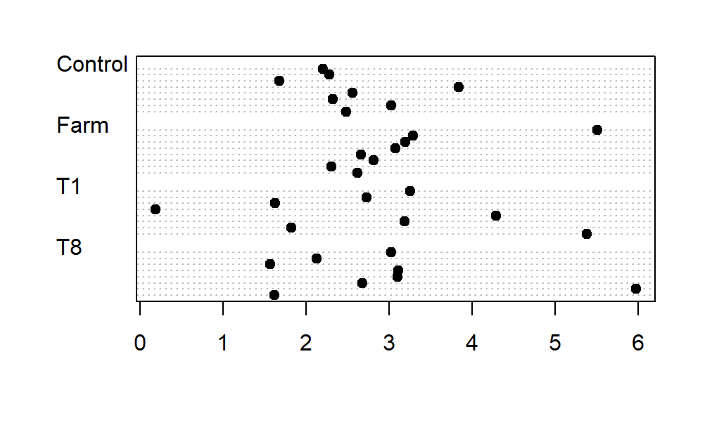

```r
dotchart(SES$SES_fbsne, group = SES$trmt, pch = 19)
```

```r
with(FS_comps, bartlett.test(SES_fbsne ~ trmt))
```

```
    Bartlett test of homogeneity of variances

data:  SES_fbsne by trmt
Bartlett's K-squared = 1.2123, df = 1, p-value = 0.2709
```

```r
with(KT_comps, bartlett.test(SES_fbsne ~ trmt))
```

```
    Bartlett test of homogeneity of variances

data:  SES_fbsne by trmt
Bartlett's K-squared = 0.14608, df = 1, p-value = 0.7023
```

```r
with(VL_comps, bartlett.test(SES_fbsne ~ trmt))
```

```
    Bartlett test of homogeneity of variances

data:  SES_fbsne by trmt
Bartlett's K-squared = 4.927, df = 1, p-value = 0.02644
```

```r
with(FS_comps, ad.test(SES_fbsne))
```

```
    Anderson-Darling normality test

data:  SES_fbsne
A = 0.91132, p-value = 0.01528
```

```r
#Failed normality test. I'm not seeing any major outliers?
with(KT_comps, ad.test(SES_fbsne))
```

```
    Anderson-Darling normality test

data:  SES_fbsne
A = 0.4654, p-value = 0.2192
```

```r
with(VL_comps, ad.test(SES_fbsne))
```

```
    Anderson-Darling normality test

data:  SES_fbsne
A = 0.31215, p-value = 0.5153
```

Skipping the non normal Francis one for now

####Katie

```r
KT_fbsne.mod.full <- glm(SES_fbsne ~ trmt + pland +  enn, family = gaussian, data = KT_comps)
summary(KT_fbsne.mod.full)
step(KT_fbsne.mod.full)
```

```r
KT_fbsne.mod.null <- glm(SES_fbsne ~ 1, family = gaussian, data = KT_comps)
summary(KT_fbsne.mod.null)
qqnorm(resid(KT_fbsne.mod.null))
qqline(resid(KT_fbsne.mod.null))
plot(simulateResiduals(KT_fbsne.mod.null))
densityPlot(rstudent(KT_fbsne.mod.null)) # check density estimate of the distribution of residuals
outlierTest(KT_fbsne.mod.null)
influenceIndexPlot(KT_fbsne.mod.null, vars = c("Cook"), id = list(n = 3))

# model comparison techniques
anova(KT_fbsne.mod.full, KT_fbsne.mod.null)
AICctab(KT_fbsne.mod.full, KT_fbsne.mod.null)
```

####Vacant Lots

```r
VL_fbsne.mod.full <- glm(SES_fbsne ~ trmt + pland +  enn, family = gaussian, data = VL_comps)
summary(VL_fbsne.mod.full)
step(VL_fbsne.mod.full)
```

```r
VL_fbsne.mod.null <- glm(SES_fbsne ~ 1, family = gaussian, data = VL_comps)
summary(VL_fbsne.mod.null)
qqnorm(resid(VL_fbsne.mod.null))
qqline(resid(VL_fbsne.mod.null))
plot(simulateResiduals(VL_fbsne.mod.null))
densityPlot(rstudent(VL_fbsne.mod.null)) # check density estimate of the distribution of residuals
outlierTest(VL_fbsne.mod.null)
influenceIndexPlot(VL_fbsne.mod.null, vars = c("Cook"), id = list(n = 3))


# model comparison techniques
anova(VL_fbsne.mod.full, VL_fbsne.mod.null)
AICtab(VL_fbsne.mod.full, VL_fbsne.mod.null)
```